# Problem Set 1

Zhengting (Johnathan) He

2021/9/2

```r
# set working directory
require(tidyverse)
setwd("D:/OneDrive - Johns Hopkins/Course/140.621.81 - Statistical Methods in Public Health I/Problem set/jhsphbiostat621-assignment/Problem set 1")
```

# Problem set 1: Displaying and Thinking About Public Health Data EDA

## Problem 1. Air Pollution and Mortality in Baltimore

### Section 1: Exploratory Data Analysis

```r
# import data
data <- read_csv("./data/baltps11.csv")
data$group <- factor(data$group, levels = c("1", "2"))
```

- 1. Create stem and leaf displays by group:

```r
for(pollut in c("1", "2")) {
    print(ifelse(pollut == "1", "# Daily mortality count on Highest Particulate Pollution Days", "# Daily mortality count on Lowest Particulate Pollution Days"))
    stem(filter(data, group == pollut)$deaths)
}
```

```
## [1] "# Daily mortality count on Highest Particulate Pollution Days"
##
##   The decimal point is 1 digit(s) to the right of the |
##
##   1 | 44
##   1 | 567778899
##   2 | 334
##   2 | 5678
##   3 | 3
##   3 | 7
##
## [1] "# Daily mortality count on Lowest Particulate Pollution Days"
##
##   The decimal point is 1 digit(s) to the right of the |
##
##   1 | 134
##   1 | 5666667899
##   2 | 0134
##   2 | 577
```

- 2. Create a box and whiskers plot by group:

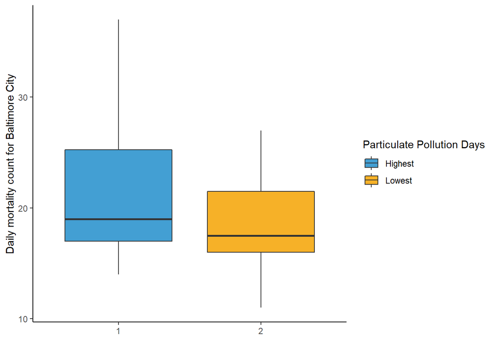

```r
ggplot(aes(x = group, y = deaths), data = data) +
    geom_boxplot(aes(fill = group)) +
    xlab("") +
    ylab("Daily mortality count for Baltimore City") +
    scale_fill_manual("Particulate Pollution Days",
                      values = c("#439fd3", "#f6b128"),
                      labels = c("Highest", "Lowest")) +
    theme_classic()
```

- 3. Please check that your results for steps a. and b. give you the same results as you obtained by hand in Lab Exercise 1.

```
# Yes.
```

- 4. In a sentence or two, as if for a public health journal, summarize the evidence from these data relevant to whether mortality tends to be higher on high particulate pollution days, as compared to low particulate pollution days. Be quantitative, that is use numeric results, to describe your findings in the context of air pollution and mortality, the topic of greatest interest to your readers. Remember units!

```
# The median daily mortality count for Baltimore city is 1.5 person higher on high particulate pollution days, compared with low particulate pollution days. Since the daily mortality counts on both high particulate pollution days and low particulate pollution days are on a right-skewed distribution, it is reasonable to use median as a summary measurement to compare.
```

- 5. To assure reproducible research, save your log file. Please include the relevant parts of your edited log file with your results as part of your write-up.

## Problem 2. Costs of Carotid Endarterectomy in Maryland

### Section 1: Exploratory Data Analysis

- 1. We have drawn a random sample of 100 male and 100 female patients from the HSCRC carotid endarterectomy data set which is located in the Stata data file named CE621.dta on the course website. Refer to your Class Dataset Code-Book for the file format. Open the data set. And, don’t forget to open a log in order to save your work. Make stem and leaf plots of the male and female CE costs.

```r
# import data
data2 <- read_csv("./data/ce621.csv")
data2$provnum <- as.numeric(data2$provnum)
data2$sex <- factor(data2$sex, levels = c("Male", "Female"))
data2$race <- factor(data2$race, levels = c("Caucas", "AfroAm", "Other"))
data2$smoker <- factor(data2$smoker, levels = c("No", "Yes"))
```

```r
for(sex in c("Male", "Female")) {
    print(paste("# CE costs for ", sex, sep = ""))
    stem(filter(data2, sex == sex)$totchg)
}
```

```
## [1] "# CE costs for Male"
##
##   The decimal point is 3 digit(s) to the right of the |
##
##    0 | 29
##    2 | 5667788990002223344445666677778899999
##    4 | 01122233333344444444455555677778999000001112222223334444556666778999
##    6 | 001122233344455566667778999900122223459
##    8 | 35577889123555779
##   10 | 12524567889
##   12 | 2588908
##   14 | 57
##   16 | 177
##   18 | 12244489
##   20 |
```

[output cut: 36 more lines]

- 2. Make the necessary calculations using Stata to complete the summary table below regarding CE costs by sex.

```r
# summary statistics
data2.summary <- data2 %>%
                     group_by(sex) %>%
                         summarise(Mean = mean(totchg, na.rm = TRUE),
                                   Median = median(totchg, na.rm = TRUE),
                                   IQR = quantile(totchg, probs = c(0.75), na.rm = TRUE) - quantile(totchg, probs = c(0.25), na.rm = TRUE),
                                   SD = sd(totchg, na.rm = TRUE))

# transform dataset to meet with the required format
data2.summary <- data2.summary %>%
                     gather(Statistic, Value, c(Mean:SD)) %>%
                         spread(sex, Value, c("Male", "Female")) %>%
                             mutate(Statistic = factor(Statistic, levels = c("Mean", "Median", "IQR", "SD"))) %>%
                                 arrange(Statistic) %>%
                                     mutate(Male = round(as.numeric(Male), 2),
                                            Female = round(as.numeric(Female), 2))
print(data2.summary)
```

```
## # A tibble: 4 x 3
##   Statistic  Male Female
##   <fct>     <dbl>  <dbl>
## 1 Mean      6484.  8099.
## 2 Median    5598.  5644.
## 3 IQR       2862.  5187
## 4 SD        3278.  6679.
```

- 3. In a brief paragraph, as if written for a health services research journal, compare the distribution of costs for men and women. Be quantitative by referring to the average cost, variability, and the shape of the distribution.

```
# The average cost of women is 1615.25 dollars higher than men, and the standard deviation of cost of female is 3401.34 dollars higher than men, indicating women have a higher variability. The shapes of the distribution of costs of both men and women are right skewed. Since the distribution of costs of both men and women are skewed, it may be more appropriate to use median and interquartile range to summary descriptive statistics. The median cost of female is slightly higher than male (46 dollars), while the interquartile range of women is 2325.5 dollars higher than men, indicating a large variability of women compared with men.
```

- 4. Now use the entire CE Stata data file named CE621entire.dta. Choose only one year and stratify the population of costs into six sex-by-age strata where age is categorized: ≤ 50 years; 51-64; 65+. Create and add value labels to the new categorized age variable. Display side-by-side six box plots (≤ 50-male, female; 51-64-male, female; 65+-male, female). Order the box plots to facilitate the sex comparison within age-group.

```r
# import dataset
data3 <- read_csv("./data/ce621entire.csv")
data3$provnum <- as.numeric(data3$provnum)
data3$sex <- factor(data3$sex, levels = c("Male", "Female"))
data3$race <- factor(data3$race, levels = c("Caucas", "AfroAm", "Other"))
data3$smoker <- factor(data3$smoker, levels = c("No", "Yes"))
```

```r
# > max(data3$age)
# [1] 92

# Categorize age and sex into composite factor variable
data3 <- data3 %>%
             filter(year == 1995) %>% # choose year 1995
                 mutate(age_cat = cut(age, breaks = c(0, 50, 64, 92))) %>%
                     mutate(agesex = case_when(age_cat == "(0,50]" & sex == "Male" ~ "1",
                                               age_cat == "(0,50]" & sex == "Female" ~ "2",
                                               age_cat == "(50,64]" & sex == "Male" ~ "3",
                                               age_cat == "(50,64]" & sex == "Female" ~ "4",
                                               age_cat == "(64,92]" & sex == "Male" ~ "5",
                                               age_cat == "(64,92]" & sex == "Female" ~ "6")) %>%
                         mutate(agesex = factor(agesex, levels = c("1", "2", "3", "4", "5", "6"),
                                                        labels = c("M <= 50", "F <= 50", "M 51-64",
                                                                   "F 51-64", "M >= 65", "F >= 65")))
```

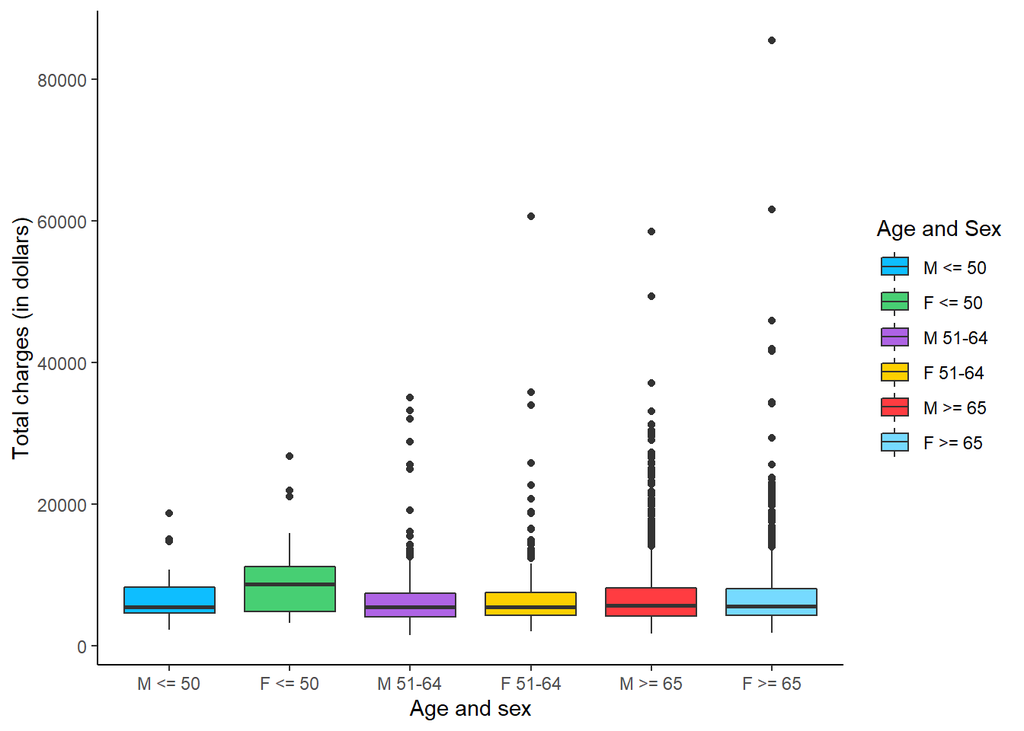

```r
ggplot(aes(x = agesex, y = totchg), data = data3) +
    geom_boxplot(aes(fill = agesex)) +
    xlab("Age and sex") +
    ylab("Total charges (in dollars)") +
    scale_fill_manual("Age and Sex",
                      values = c("#0ebeff", "#47cf73", "#ae63e4", "#fcd000", "#ff3c41", "#76daff")) +
    theme_classic()
```

- 22. Write a sentence or two that describe how the CE cost distribution differs for men and women within each of the three age strata. From an equivalent but alternate perspective, describe how the distribution varies across age separately for men and women.

```
In the year 1995, in all age and sex groups, the distributions of total charges in dollars are right skewed. Among age <= 50 years, both median and interquartile range of men are lower than women. While among age group 51-64 and 65+, both median and interquartile range of men are slightly higher than women.
# <= 50: median: M < F, IQR: M < F
# 51 - 64: median: M > F, IQR: M > F
# >= 65: median: M > F, IQR: M > F
```